# *Word Embeddings*

## *What is Word Embedding?*

*Embedding mathematically represents a mapping , f: X-> Y, which is a function.*

*Where the function is*

- *injective* *(each Y has a unique X correspondence, and vice versa.)*
- *structure-preserving* *(structure preservation , for example, X1 < X2 in the space to which X belongs, then the same applies to Y1 <Y2 in the space to which Y belongs after mapping.)*

*So for word embedding, the word is mapped to another space, where this mapping has the characteristics of injective and structure-preserving.*

*Word embedding is a form of word representation that connects the human understanding of language to that of the machine. Word embeddings are the distributed representations of text in an ample dimensional space. By looking at different researches in the area of deep learning, word embeddings are essential. It is the approach of representing words and documents that may be considered as one of the crucial breakthroughs in the field of deep learning on challenging NLP problems.*

*Word embeddings are a class of techniques where the individual word, is represented as a real-valued vector in a vector space. The main idea is to use a densely distributed representation for all the words. Each word is represented by a real-value vector.* *Each word is mapped to a single vector, and the vector values are learned in a way that resembles a neural network, and hence the technique is often lumped into the field of deep learning.*

## *Where is Word Embedding used?*

*Word embedding helps in feature generation, document clustering, text classification, and natural language processing tasks. Let us list them and have some discussion on each of these applications.*

- *Compute similar words* *: Word embedding is used to suggest similar words to the word being subjected to the prediction model. Along with that it also suggests dissimilar words, as well as most common words.*
- *Create a group of related words* *: It is used for semantic grouping which will group things of similar characteristic together and dissimilar far away.*
- *Feature for text classification* *: Text is mapped into arrays of vectors which is fed to the model for training as well as prediction. Text-based classifier models cannot be trained on the string, so this will convert the text into machine trainable form. Further its features of building semantic help in text-based classification.*
- *Document clustering* *is another application where word embedding is widely used*
- *Natural language processing* *: There are many applications where word embedding is useful and wins over feature extraction phases such as parts of speech tagging, sentimental analysis, and syntactic analysis.*

## *Popular off-the-shelf Word Embedding Models*

- *Word2Vec* *(by Google)*
- *GloVe* *(by Stanford)*
- *fastText* *(by Facebook)*

*[Reference](https://towardsdatascience.com/word-embeddings-exploration-explanation-and-exploitation-with-code-in-python-5dac99d5d795)*

## *What is the problem with bag of words?*

*In the bag of words model, each document is represented as a word-count vector. These counts can be binary counts, a word may occur in the text or not or will have absolute counts. The size of the vector is equal to the number of elements in the vocabulary. If most of the elements are zero then the bag of words will be a sparse matrix.*

*In deep learning, we would have sparse matrix as we will be working with huge amount of training data. Sparse representations are harder to model both for computational reasons as well as for informational reasons.*

- *Huge amount of weights* *: Huge input vectors means a huge number of weights for a neural network.*
- *Computationally intensive* *: More weights means more computation required to train and predict.*
- *Lack of meaningful relations and no consideration for order of words* *: BOW is a collection of words that appear in the text or sentences with the word counts. Bag of words does not take into consideration the order in which they appear.*

## *How Word Embedding Solves this?*

*Embeddings translate large sparse vectors into a lower-dimensional space that preserves semantic relationships. Word embeddings is a technique where individual words of a domain or language are represented as real-valued vectors in a lower dimensional space.*

*Sparse Matrix problem with BOW is solved by mapping high-dimensional data into a lower-dimensional space.*

*Lack of meaningful relationship issue of BOW is solved by placing vectors of semantically similar items close to each other. This way words that have similar meaning have similar distances in the vector space.*

# *word2vec*

## *What is word2vec?*

*Word2vec is the technique/model to produce word embedding for better word representation. It captures a large number of precise syntactic and semantic word relationship. It is a shallow two-layered neural network. Before going further, please see the difference between shallow and deep neural network:*

*The shallow neural network consists of the only a hidden layer between input and output whereas deep neural network contains multiple hidden layers between input and output. Input is subjected to nodes whereas the hidden layer, as well as the output layer, contains neurons.*

*word2vec is a two-layer network where there is input one hidden layer and output.*

*Word2vec was developed by a group of researcher headed by Tomas Mikolov at Google. Word2vec is better and more efficient that latent semantic analysis model.*

## *What word2vec does?*

*Word2vec represents words in vector space representation. Words are represented in the form of vectors and placement is done in such a way that similar meaning words appear together and dissimilar words are located far away. This is also termed as a semantic relationship. Neural networks do not understand text instead they understand only numbers. Word Embedding provides a way to convert text to a numeric vector.*

*Word2vec reconstructs the linguistic context of words. Before going further let us understand, what is linguistic context? In general life scenario when we speak or write to communicate, other people try to figure out what is objective of the sentence. For example, "What is the temperature of India", here the context is the user wants to know "temperature of India" which is context. In short, the main objective of a sentence is context. Word or sentence surrounding spoken or written language (disclosure) helps in determining the meaning of context. Word2vec learns vector representation of words through the contexts.*

## *How Word2vec works?*

*Word2vec learns word by predicting its surrounding context. For example, let us take the word "He loves Football."*

*We want to calculate the word2vec for the word: loves.*

```
loves =  Vin. P(Vout / Vin) is calculated
where,
Vin is the input word.
P is the probability of likelihood.
Vout is the output word.
```

*Word loves moves over each word in the corpus. Syntactic as well as the Semantic relationship between words is encoded. This helps in finding similar and analogies words.*

*All random features of the word loves is calculated. These features are changed or update concerning neighbor or context words with the help of a back propagation method.*

*Another way of learning is that if the context of two words are similar or two words have similar features, then such words are related.*

## *Word2vec Architecture*

*There are two architectures used by word2vec*

- *Continuous Bag of words (CBOW)*
- *skip gram*

*Before going further, let us discuss why these architectures or models are important from word representation point of view. Learning word representation is essentially unsupervised, but targets/labels are needed to train the model. Skip-gram and CBOW convert unsupervised representation to supervised form for model training.*

*In CBOW, the current word is predicted using the window of surrounding context windows. For example, if wi-1,wi-2,wi+1,wi+2are given words or context, this model will provide wi*

*Skip-Gram performs opposite of CBOW which implies that it predicts the given sequence or context from the word. You can reverse the example to understand it. If wi is given, this will predict the context or wi-1,wi-2,wi+1,wi+2.*

*Word2vec provides an option to choose between CBOW (continuous Bag of words) and skim-gram. Such parameters are provided during training of the model.*

[figure not shown]

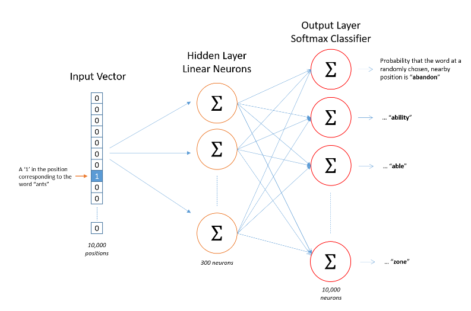

### *CBOW (Continuous Bag of words)*

_The CBOW model architecture tries to predict the current target word (the center word) based on the source context words (surrounding words). Considering a simple sentence, “the quick brown fox jumps over the lazy dog”, this can be pairs of (context_window, target_word) where if we consider a context window of size 2, we have examples like ([quick, fox], brown), ([the, brown], quick), ([the, dog], lazy) and so on. Thus the model tries to predict the **target_word** based on the **context_window** words._

*While the Word2Vec family of models are unsupervised, what this means is that you can just give it a corpus without additional labels or information and it can construct dense word embeddings from the corpus.*

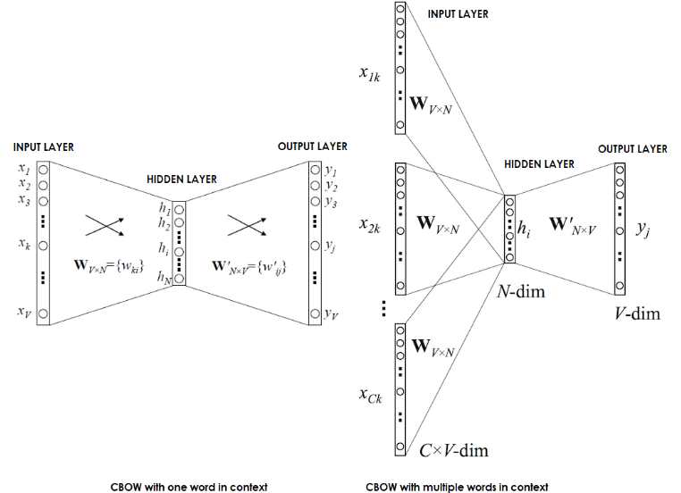

#### *CBOW with one word in context*

*Suppose, we have a corpus C = “Hey, this is sample corpus using only one context word.” and we have defined a context window of 1. This corpus may be converted into a training set for a CBOW model as follow. The input is shown below. The matrix on the right in the below image contains the one-hot encoded from of the input on the left.*

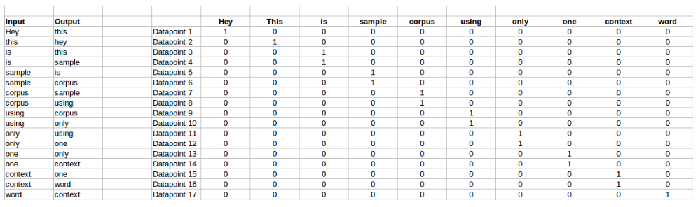

*The target for a single datapoint say Datapoint 4 is shown as below:*

| Hey | this | is | sample | corpus | using | only | one | context | word |
| --- | --- | --- | --- | --- | --- | --- | --- | --- | --- |
| 0 | 0 | 0 | 1 | 0 | 0 | 0 | 0 | 0 | 0 |

*This matrix shown in the above image is sent into a shallow neural network with three layers: an input layer, a hidden layer and an output layer. The output layer is a softmax layer which is used to sum the probabilities obtained in the output layer to 1. Now let us see how the forward propagation will work to calculate the hidden layer activation.*

*The flow is as follows:*

- *The input layer and the target, both are one- hot encoded of size [1 X V]. Here V=10 in the above example.*
- *There are two sets of weights. one is between the input and the hidden layer and second between hidden and output layer.*
- *Input-Hidden layer matrix size =[V X N] , hidden-Output layer matrix size =[N X V] : Where N is the number of dimensions we choose to represent our word in. It is arbitary and a hyper-parameter for a Neural Network. Also, N is the number of neurons in the hidden layer. Here, N=4.*
- *There is a no activation function between any layers.( More specifically, I am referring to linear activation)*
- *The input is multiplied by the input-hidden weights and called hidden activation. It is simply the corresponding row in the input-hidden matrix copied.*
- *The hidden input gets multiplied by hidden- output weights and output is calculated.*
- *Error between output and target is calculated and propagated back to re-adjust the weights.*
- *The weight between the hidden layer and the output layer is taken as the word vector representation of the word.*

#### *CBOW with multiple words in context*

*So, the input layer will have 3 [1 X V] Vectors in the input as shown above and 1 [1 X V] in the output layer. Rest of the architecture is same as for a 1-context CBOW.*

*The steps remain the same, only the calculation of hidden activation changes. Instead of just copying the corresponding rows of the input-hidden weight matrix to the hidden layer, an average is taken over all the corresponding rows of the matrix. We can understand this with the above figure. The average vector calculated becomes the hidden activation. So, if we have three context words for a single target word, we will have three initial hidden activations which are then averaged element-wise to obtain the final activation.*

#### *Advantages of CBOW*

- *Being probabilistic is nature, it is supposed to perform superior to deterministic methods(generally).*
- *It is low on memory. It does not need to have huge RAM requirements like that of co-occurrence matrix where it needs to store three huge matrices.*

#### *Disadvantages of CBOW*

- *CBOW takes the average of the context of a word (as seen above in calculation of hidden activation). For example, Apple can be both a fruit and a company but CBOW takes an average of both the contexts and places it in between a cluster for fruits and companies.*
- *Training a CBOW from scratch can take forever if not properly optimized.*

### *Skip-Gram*

*Skip – gram follows the same topology as of CBOW. It just flips CBOW’s architecture on its head. The aim of skip-gram is to predict the context given a word.*

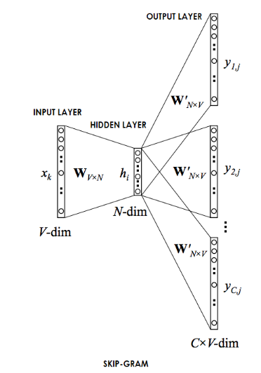

*Let us take the same corpus that we built our CBOW model on. C=”Hey, this is sample corpus using only one context word.” Let us construct the training data.*

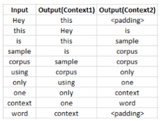

*The input vector for skip-gram is going to be similar to a 1-context CBOW model. Also, the calculations up to hidden layer activations are going to be the same. The difference will be in the target variable. Since we have defined a context window of 1 on both the sides, there will be “two” one hot encoded target variables and “two” corresponding outputs.*

*Two separate errors are calculated with respect to the two target variables and the two error vectors obtained are added element-wise to obtain a final error vector which is propagated back to update the weights.*

*The weights between the input and the hidden layer are taken as the word vector representation after training. The loss function or the objective is of the same type as of the CBOW model.*

#### *Advantages of Skip-Gram Model*

- *Skip-gram model can capture two semantics for a single word. i.e it will have two vector representations of Apple. One for the company and other for the fruit.*
- *Skip-gram with negative sub-sampling outperforms every other method generally.*